# Estadísticas comerciales del proyecto: E-news Express

**Puntos: 60**

# Definir el enunciado del problema y los objetivos

## Enunciado del problema:

En el contexto empresarial actual, los portales de noticias electronicas representan una valiosa herramienta para obtener actualizaciones rápidas sobre eventos diarios a nivel mundial. E-news Express, un portal de noticias en línea, busca expandir su negocio adquiriendo nuevos suscriptores. Sin embargo, la compañia enfrenta una disminución en el número de suscriptores mensuales a comparación del año anterior. Los ejecutivos de E-news Express cree que esta disminución se debe a que la página web actual no está adecuadamente diseñada en términos de esquema y contenido recomendado para mantener a los usuarios comprometidos el tiempo suficiente y motivarlos a suscribirse.

## Objetivos a solventar:

El objectivo principal es evaluar la eficacia de una nueva página de inicio que ha sido desarrollada y diseñada para el portal. Para alcanzar este objetivo, se llevará a cabo un análisis estadístico utilizando una técnica experimental conocida como prueba A/B, en la que 100 usuarios seleccionados al azar se dividirán en dos grupos igualmente distribuidos. Un grupo de usuarios verá la página de inicio existente (grupo de control), mientras que el otro grupo de usuarios verá la nueva página de inicio (grupo de tratamiento).

### Los siguientes objetivos especificos deben ser abordados:

1. Determinar si los usuarios pasan más tiempo en la nueva página de inicio en comparación con la página de inicio existente. Este análisis ayudará a comprender si el nuevo diseño logra mantener a los usuarios comprometidos por más tiempo.
2. Evaluar si la tasa de conversión en la nueva página de inicio es mayor que la tasa de conversión en la pagina de inicio existente. La tasa de conversión representa la proporción de usuarios que visitan la página de inicio y deciden suscribirse. Este resultado indicará si el nuevo diseño mejora la capacidad de convertir visitantes en suscriptores.
3. Investigar si el estatus de conversión depende del idioma preferido de los usuarios. Se creará una tabla de contingencia para analizar cómo la elección del idioma puede afectar las tasas de conversión en ambas páginas.
4. Determinar si el tiempo dedicado a la nueva página de inicio es similar entre los usuarios que prefieren diferentes idiomas. Este análisis permitirá identificar si la duración del timepo de interacción con la nueva p+agina varía según el idioma preferido.

Al abordar estos objetivos, se busca proporcionar información valiosa a E-news Express para tomar decisiones informadas sobre la implementación de la nueva página de inicio y mejorar la adquisición de nuevos suscriptores en el portal de noticias.

## Diccionario de datos:

1. user_id: ID de usuario único de la persona que visita el sitio web
   1. group: si el usuario pertenece al primer grupo (control) o al segundo grupo (tratamiento)
2. landing_page: si la página de inicio es nueva o antigua
   1. time_spent_on_the_page: tiempo (en minutos) invertido por el usuario en la página de inicio
1. converted: si el usuario se convierte en suscriptor del portal de noticias o no
   1. language_preferred: idioma elegido por el usuario para ver la página de inicio

## Importar todas las bibliotecas necesarias

```python
import numpy as np
import pandas as pd
from matplotlib import pyplot as plt
import seaborn as sns
```

```python
pd.set_option('display.float_format', lambda x: '%.3f' % x)
```

## Leer los datos en un Dataframe

```python
df = pd.read_csv('abtest.csv')
```

## Explore el conjunto de datos y extraiga información mediante el análisis exploratorio de datos

- Resumen de datos
  - Ver la primera y la última fila del conjunto de datos
  - Comprobación de la forma del conjunto de datos.
  - Obtener el resumen estadístico de las variables.
- Comprobar valores perdidos
- Buscar duplicados

```python
df.head() ##mostrar los 5 primeros elementos del dataframe
```

|  | user_id | group | landing_page | time_spent_on_the_page | converted | language_preferred |
| --- | --- | --- | --- | --- | --- | --- |
| 0 | 546592 | control | old | 3.48 | no | Spanish |
| 1 | 546468 | treatment | new | 7.13 | yes | English |
| 2 | 546462 | treatment | new | 4.40 | no | Spanish |
| 3 | 546567 | control | old | 3.02 | no | French |
| 4 | 546459 | treatment | new | 4.75 | yes | Spanish |

```python
df.tail() ##mostrar los ultimos 5 elementos del dataframe
```

|  | user_id | group | landing_page | time_spent_on_the_page | converted | language_preferred |
| --- | --- | --- | --- | --- | --- | --- |
| 95 | 546446 | treatment | new | 5.15 | no | Spanish |
| 96 | 546544 | control | old | 6.52 | yes | English |
| 97 | 546472 | treatment | new | 7.07 | yes | Spanish |
| 98 | 546481 | treatment | new | 6.20 | yes | Spanish |
| 99 | 546483 | treatment | new | 5.86 | yes | English |

```python
print("There are", df.shape[0], 'rows and', df.shape[1], "columns.") ##muesta la estructuras del dataframe
```

```
There are 100 rows and 6 columns.
```

```python
df.info() ## se muestra un resumen conciso del dataframe
```

```
<class 'pandas.core.frame.DataFrame'>
RangeIndex: 100 entries, 0 to 99
Data columns (total 6 columns):
 #   Column                  Non-Null Count  Dtype
---  ------                  --------------  -----
 0   user_id                 100 non-null    int64
 1   group                   100 non-null    object
 2   landing_page            100 non-null    object
 3   time_spent_on_the_page  100 non-null    float64
 4   converted               100 non-null    object
 5   language_preferred      100 non-null    object
dtypes: float64(1), int64(1), object(4)
memory usage: 4.8+ KB
```

Podemos ver que hay 6 tipos de variables con 100 observaciones. tambien podemos observar que 4 de 6 variables son de tipo objeto.

```python
df.describe(include ='all').T
```

|  | count | unique | top | freq | mean | std | min | 25% | 50% | 75% | max |
| --- | --- | --- | --- | --- | --- | --- | --- | --- | --- | --- | --- |
| user_id | 100.000 | NaN | NaN | NaN | 546517.000 | 52.296 | 546443.000 | 546467.750 | 546492.500 | 546567.250 | 546592.000 |
| group | 100 | 2 | control | 50 | NaN | NaN | NaN | NaN | NaN | NaN | NaN |
| landing_page | 100 | 2 | old | 50 | NaN | NaN | NaN | NaN | NaN | NaN | NaN |
| time_spent_on_the_page | 100.000 | NaN | NaN | NaN | 5.378 | 2.378 | 0.190 | 3.880 | 5.415 | 7.022 | 10.710 |
| converted | 100 | 2 | yes | 54 | NaN | NaN | NaN | NaN | NaN | NaN | NaN |
| language_preferred | 100 | 3 | Spanish | 34 | NaN | NaN | NaN | NaN | NaN | NaN | NaN |

Aquí podemos observar un resumen estadistico de las variables

con respecto a las variables de tipo objeto podemos observar lo siguiente:

la variable "converted" cuenta con 2 tipos de categorias, las cuales son "yes" y "no". siendo "yes" la categoria que más se repite.

```python
df.isnull().sum()
```

```
user_id                   0
group                     0
landing_page              0
time_spent_on_the_page    0
converted                 0
language_preferred        0
dtype: int64
```

Podemos observar que no hay valores perdidos en el dataframe.

```python
df.duplicated().sum()
```

```
0
```

Tambien podemos observar que no hay valores duplicados.

### Análisis univariado

Primero analizaremos las variables categoricas.

se realiza un value_counts() de todas las variables.

```python
count_group = df['group'].value_counts()
count_landing_page = df['landing_page'].value_counts()
count_converted = df['converted'].value_counts()
count_language_preferred = df['language_preferred'].value_counts()

# Concatena los conteos en un solo dataframe
all_counts = pd.concat([count_group, count_landing_page, count_converted, count_language_preferred], axis=1)

# Renombra las columnas para mayor claridad
all_counts.columns = ['group', 'landing_page', 'converted', 'language_preferred']

# Imprime los conteos de todas las variables categóricas en un solo dataframe
print(all_counts)
```

```
           group  landing_page  converted  language_preferred
control   50.000           NaN        NaN                 NaN
treatment 50.000           NaN        NaN                 NaN
old          NaN        50.000        NaN                 NaN
new          NaN        50.000        NaN                 NaN
yes          NaN           NaN     54.000                 NaN
no           NaN           NaN     46.000                 NaN
Spanish      NaN           NaN        NaN              34.000
French       NaN           NaN        NaN              34.000
English      NaN           NaN        NaN              32.000
```

A continuacion se mostraran las countplots correspondientes de cada variable.

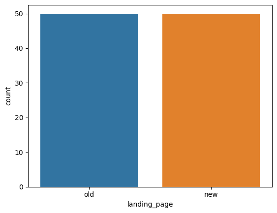

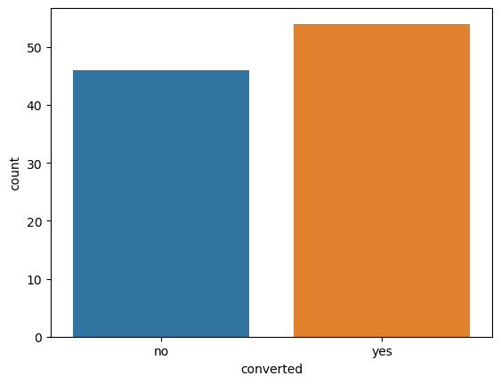

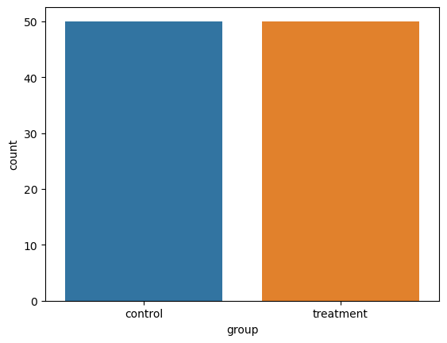

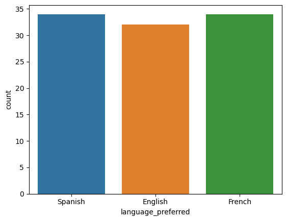

```python
sns.countplot(data=df,x='landing_page')
plt.show()

sns.countplot(data=df,x='converted')
plt.show()

sns.countplot(data=df,x='group')
plt.show()

sns.countplot(data=df,x='language_preferred')
plt.show()
```

Al observar las countplots podemos hacer las siguientes observaciones:

- Existen los mismos usuarios tanto en la nueva pagina de inicio como en la vieja.
- Podemos ver que 54 usuarios adquieren una suscripcion vs 46 que no lo hacen.
- Existe la misma cantidad de usarios en los 2 grupos.
- Podemos observar que entre los 3 idiomas, los que más destacan son "Spanish" y "French" teniendo la misma cantidad de usuarios con ese idioma preferido.

Ahora se analizara la variable númerica.

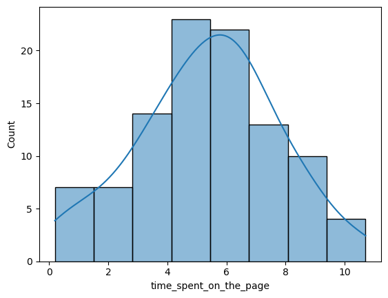

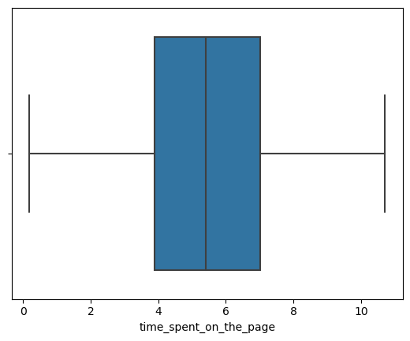

```python
sns.histplot(data=df,x='time_spent_on_the_page', kde = True)
plt.show()
sns.boxplot(data=df,x='time_spent_on_the_page')
plt.show()
```

- Podemos observar que los datos cuentan con una distribución normal.
- Tambien podemos ver que la media de los datos se encuentra en 5.37 min, sin presentar valores atípicos.

### Análisis bivariado

A continuacion se realizará el analisis bivariado para poder observar las relaciones que hay entre las variables.

### Converted vs Time_spent_on_the_page

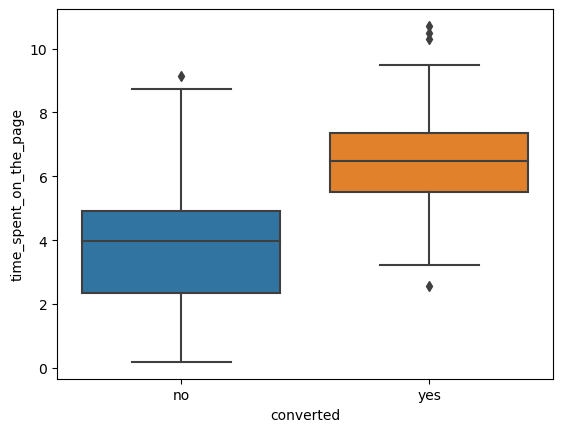

```python
sns.boxplot(data=df,x='converted',y='time_spent_on_the_page')
plt.show()
```

### Landing_page vs Time_spent_on_the_page

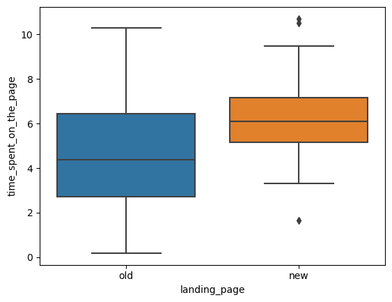

```python
sns.boxplot(data=df,x='landing_page',y='time_spent_on_the_page')
plt.show()
```

### Language_preferred vs Time_spent_on_the_page

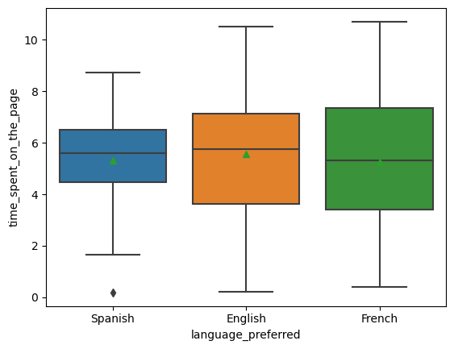

```python
sns.boxplot(data = df, x = 'language_preferred', y = 'time_spent_on_the_page', showmeans = True)
plt.show()
```

### Observaciones

- Podemos observar que las personas que pasan más tiempo en la pagina de inicio, terminan adquiriendo una suscripción.
- De igual manera podemos observar que los usuarios pasan más tiempo en la pagina de inicio nueva, que en la antigua.
- Se puede ver que el idioma no es una variable que afecte tanto el tiempo que el usuario pasa en la pagina de inicio, ya que se puede observar que el tiempo promedio es casi el mismo en cualquiera de los 3 idiomas.

Tambien podemos observar que en 2 de las graficas hay valores atipicos cuando el usuario es un suscriptor y visualiza la página nueva. asi podemos decir que quizá la nueva pagina tiene cierto contenido de noticias o estructura en general que le interesa a los usuarios y los alienta a consumir más su contenido y por lo tanto terminan convirtiendose en suscriptores.

## 1. ¿Pasan los usuarios más tiempo en la nueva página de destino que en la página de destino existente?

### Realizar análisis visual

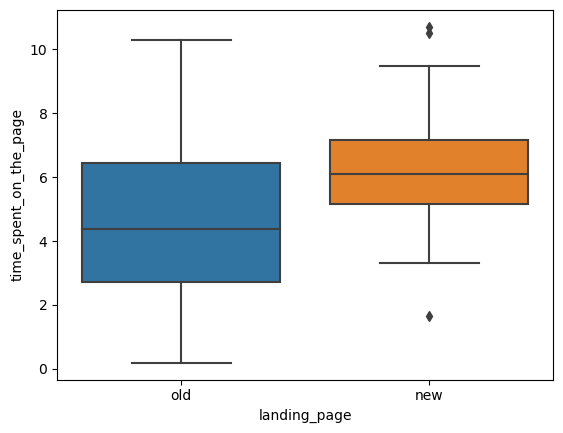

```python
sns.boxplot(data=df,x='landing_page',y='time_spent_on_the_page')
plt.show()
```

### Paso 1: Definir las hipótesis nula y alternativa

> Hipótesis nula $H_0:$ No hay diferencia significativa en el tiempo que los usuarios pasan en la nueva página de destino en comparación con la página de destino existente.

### Paso 2: Seleccione la prueba adecuada

Para determinar si hay una diferencia significativa en el tiempo que los usuarios pasan en la nueva página de destino en comparación con la página de destino existente, la prueba adecuada es una prueba de hipótesis para comparar las medias de dos muestras independientes.

En este caso, se tiene una muestra de usuarios que interactuaron con la nueva página de destino (grupo de tratamiento) y otra muestra de usuarios que interactuaron con la página de destino existente (grupo de control). Queremos comparar si las medias de tiempo dedicado en ambas muestras son diferentes y si esta diferencia es estadísticamente significativa.

Utilizaremos una 'prueba t independiente de dos muestras' para comparar los tiempos de ambos grupos y determinar si la diferencia es significativa o si no hay alguna diferencia.

### Paso 4: recopilar y preparar datos

```python
# Filtrar los datos para obtener solo las observaciones de la página de inicio nueva
nueva_page_data = df[df['landing_page'] == 'new']

# Calcular la desviación estándar del tiempo que los usuarios pasan en la página de inicio nueva
desviacion_estandar_nueva_page = nueva_page_data['time_spent_on_the_page'].std()

# Filtrar los datos para obtener solo las observaciones de la página de inicio existente
existente_page_data = df[df['landing_page'] == 'old']

# Calcular la desviación estándar del tiempo que los usuarios pasan en la página de inicio existente
desviacion_estandar_existente_page = existente_page_data['time_spent_on_the_page'].std()

print("Desviación estándar del tiempo en la página de inicio nueva:", desviacion_estandar_nueva_page)
print("Desviación estándar del tiempo en la página de inicio existente:", desviacion_estandar_existente_page)
```

```
Desviación estándar del tiempo en la página de inicio nueva: 1.8170310387878263
Desviación estándar del tiempo en la página de inicio existente: 2.581974849306046
```

### Paso 5: Calcular el valor p

```python
from scipy import stats
# Filtrar los datos para obtener solo las observaciones de la página de inicio nueva
nueva_page_data = df[df['landing_page'] == 'new']

# Filtrar los datos para obtener solo las observaciones de la página de inicio existente
existente_page_data = df[df['landing_page'] == 'old']

# Realizar la prueba t independiente de dos muestras
t_statistic, p_value = stats.ttest_ind(nueva_page_data['time_spent_on_the_page'], existente_page_data['time_spent_on_the_page'], equal_var=False, alternative = 'greater')

print("Valor p:", p_value)
```

```
Valor p: 0.0001392381225166549
```

### Paso 6: Compare el valor p con $\alpha$

```python
# Nivel de significancia alfa (usualmente 0.05)
alfa = 0.05

if p_value < alfa:
    print("El valor p es menor que 𝛼 (", alfa, "), por lo tanto, rechazamos la hipótesis nula.")
else:
    print("El valor p es mayor o igual que 𝛼 (", alfa, "), por lo tanto, no rechazamos la hipótesis nula.")
```

```
El valor p es menor que 𝛼 ( 0.05 ), por lo tanto, rechazamos la hipótesis nula.
```

### Paso 7: Extraer inferencia

El valor p es menor que 𝛼 ( 0.05 ), por lo tanto, rechazamos la hipótesis nula. de esta manera podemos concluir que tenemos suficiente informacion para decir que la diferencia de tiempo que pasan los usuarios en la pagina nueva es significativamente mayor a comparacion del tiempo que pasan en la pagina antigua.

**Se puede seguir un enfoque similar para responder a las otras preguntas.**

## 2. ¿La tasa de conversión (la proporción de usuarios que visitan la página de destino y se convierten) de la página nueva es mayor que la tasa de conversión de la página anterior?

### Realizar análisis visual

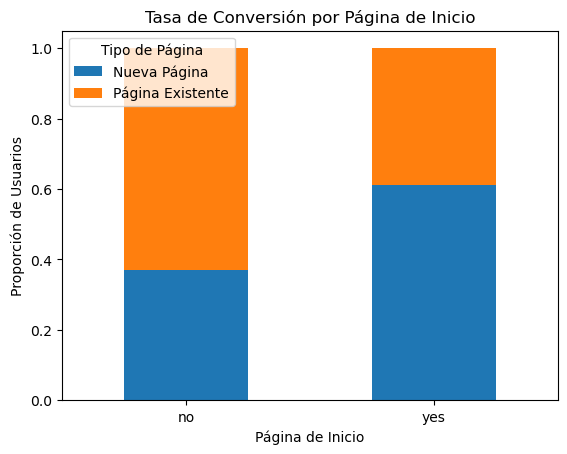

```python
pd.crosstab(df['converted'],df['landing_page'],normalize='index').plot(kind="bar",stacked=True)
plt.legend()
plt.xlabel('Página de Inicio')
plt.ylabel('Proporción de Usuarios')
plt.title('Tasa de Conversión por Página de Inicio')
plt.legend(title='Tipo de Página', loc='upper left', labels=['Nueva Página', 'Página Existente'])
plt.xticks(rotation=0)
plt.show()
```

- Podemos observar que los usuarios que más adquieren una suscripcion son usuarios que visitan la pagina nueva.

### Paso 1: Definir las hipótesis nula y alternativa

> Hipótesis nula $H_0:$ La tasa de conversión de la página nueva es igual o menor que la tasa de conversión de la página anterior.

> Hipótesis alternativa $H_a:$ La tasa de conversión de la página nueva es mayor que la tasa de conversión de la página anterior.

### Paso 2: Seleccione la prueba adecuada

La prueba estadística adecuada para este problema es la "Prueba Z de proporción de dos muestras". Esta prueba se utiliza cuando queremos comparar dos proporciones de población en dos grupos independientes. Al ser una prueba de una cola, nos permitirá determinar si la proporción de usuarios que se convierten en la página nueva es significativamente mayor que la proporción de usuarios que se convierten en la página anterior, en función de nuestros datos muestrales.

### Paso 4: recopilar y preparar datos

```python
# Filtrar los datos para obtener solo los usuarios convertidos en la página nueva y antigua
old_page_converted = df[(df['group'] == 'control') & (df['converted'] == 'yes')].shape[0]
new_page_converted = df[(df['group'] == 'treatment') & (df['converted'] == 'yes')].shape[0]

# Mostrar los números de usuarios convertidos en la nueva y antigua página
print('Número de usuarios convertidos en la nueva página: {0}'.format(new_page_converted))
print('Número de usuarios convertidos en la página antigua: {0}'.format(old_page_converted))

# Calcular el número total de usuarios en el grupo de control y el grupo de tratamiento
control_group = df[df['group'] == 'control'].shape[0]
treatment_group = df[df['group'] == 'treatment'].shape[0]

# Mostrar los números de usuarios atendidos en la nueva y antigua página
print('Número total de usuarios en el grupo de control: {0}'.format(control_group))
print('Número total de usuarios en el grupo de tratamiento: {0}'.format(treatment_group))
```

```
Número de usuarios convertidos en la nueva página: 33
Número de usuarios convertidos en la página antigua: 21
Número total de usuarios en el grupo de control: 50
Número total de usuarios en el grupo de tratamiento: 50
```

### Paso 5: Calcular el valor p

```python
from statsmodels.stats.proportion import proportions_ztest

# encontrar el p value
test_stat, p_value = proportions_ztest([new_page_converted, old_page_converted] , [treatment_group, control_group], alternative = 'larger')
print('The p-value is', p_value)
```

```
The p-value is 0.008026308204056278
```

### Paso 6: Compare el valor p con $\alpha$

```python
# Nivel de significancia alfa (usualmente 0.05)
alfa = 0.05

if p_value < alfa:
    print("El valor p es menor que 𝛼 (", alfa, "), por lo tanto, rechazamos la hipótesis nula.")
else:
    print("El valor p es mayor o igual que 𝛼 (", alfa, "), por lo tanto, no rechazamos la hipótesis nula.")
```

```
El valor p es menor que 𝛼 ( 0.05 ), por lo tanto, rechazamos la hipótesis nula.
```

### Paso 7: Extraer inferencia

El valor p es menor que 𝛼 ( 0.05 ), por lo tanto, rechazamos la hipótesis nula. Por lo tanto, tenemos suficiente información para decir que los usuarios de la pagina nueva tienden más a convertirse en suscriptores que en la pagina antigua.

## 3. ¿La conversión y el idioma preferido son independientes o están relacionados?

### Realizar análisis visual

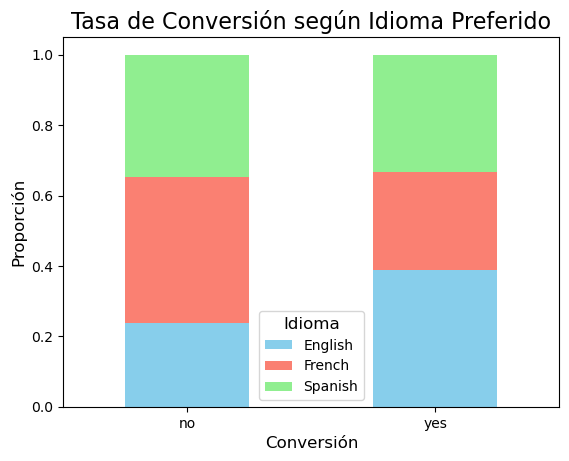

```python
tabla_conversiones_idioma = pd.crosstab(df['converted'], df['language_preferred'], normalize='index')
ax = tabla_conversiones_idioma.plot(kind='bar', stacked=True, color=['skyblue', 'salmon', 'lightgreen'])
plt.title('Tasa de Conversión según Idioma Preferido', fontsize=16)
plt.xlabel('Conversión', fontsize=12)
plt.ylabel('Proporción', fontsize=12)
plt.xticks(rotation=0)
plt.legend(title='Idioma', fontsize=10, title_fontsize=12)
plt.show()
```

### Paso 1: Definir las hipótesis nula y alternativa

> Hipótesis nula $H_0:$ La conversión y el idioma preferido son independientes, es decir, no hay ninguna relación significativa entre ellos en la población.

> Hipótesis alternativa $H_a:$ La conversión y el idioma preferido están relacionados, es decir, existe una relación significativa entre ellos en la población.

### Paso 2: Seleccione la prueba adecuada

En este caso, se utilizara la prueba de Chi-cuadrado, esta se utiliza para evaluar la asociación entre dos variables categóricas y determinar si las diferencias observadas entre las frecuencias observadas y esperadas son estadisticamente significativas.

en este caso en particular, la prueba Chi-cuadrado nos permitirá analizar si la distribución de conversiones difiere significativamente entre los diferentes idiomas preferidos en la población.

### Paso 4: recopilar y preparar datos

```python
# Filtrar los datos para obtener solo los usuarios que se han convertido y los que no se han convertido
converted_users = df[df['converted'] == 'yes']
non_converted_users = df[df['converted'] == 'no']

# Calcular la tabla de contingencia para las variables 'converted' (conversión) e 'language_preferred' (idioma preferido) para los usuarios convertidos
contingency_table_converted = pd.crosstab(converted_users['converted'], converted_users['language_preferred'])

# Calcular la tabla de contingencia para las variables 'converted' (conversión) e 'language_preferred' (idioma preferido) para los usuarios no convertidos
contingency_table_non_converted = pd.crosstab(non_converted_users['converted'], non_converted_users['language_preferred'])

# Mostrar el resultado de la tabla de contingencia para usuarios convertidos
print("Tabla de Contingencia para Usuarios Convertidos - Conversión vs Idioma Preferido:")
print(contingency_table_converted)
print("\n")

# Mostrar el resultado de la tabla de contingencia para usuarios no convertidos
print("Tabla de Contingencia para Usuarios No Convertidos - Conversión vs Idioma Preferido:")
print(contingency_table_non_converted)
print("\n")
```

```
Tabla de Contingencia para Usuarios Convertidos - Conversión vs Idioma Preferido:
language_preferred  English  French  Spanish
converted
yes                      21      15       18


Tabla de Contingencia para Usuarios No Convertidos - Conversión vs Idioma Preferido:
language_preferred  English  French  Spanish
converted
no                       11      19       16
```

### Paso 5: Calcular el valor p

```python
from scipy.stats import chi2_contingency

# Calcular la tabla de contingencia para las variables 'converted' (conversión) e 'language_preferred' (idioma preferido)
contingency_table = pd.crosstab(df['converted'], df['language_preferred'])

# Realizar el chi-cuadrado de independencia y obtener el valor p
chi2, p_value, _, _ = chi2_contingency(contingency_table)

# Mostrar el valor p
print("Valor p:", p_value)
```

```
Valor p: 0.21298887487543447
```

### Paso 6: Compare el valor p con $\alpha$

```python
# Nivel de significancia alfa (usualmente 0.05)
alfa = 0.05

if p_value < alfa:
    print("El valor p es menor que 𝛼 (", alfa, "), por lo tanto, rechazamos la hipótesis nula.")
else:
    print("El valor p es mayor o igual que 𝛼 (", alfa, "), por lo tanto, no rechazamos la hipótesis nula.")
```

```
El valor p es mayor o igual que 𝛼 ( 0.05 ), por lo tanto, no rechazamos la hipótesis nula.
```

### Paso 7: Extraer inferencia

El valor p es mayor o igual que 𝛼 ( 0.05 ), por lo tanto, no rechazamos la hipótesis nula. por lo tanto no tenemos informacion suficiente para decir que las suscripciones estan relacionadas significativamente al idioma preferido del usuario.

## 4. ¿El tiempo dedicado a la nueva página es el mismo para los diferentes usuarios de idiomas?

### Realizar análisis visual

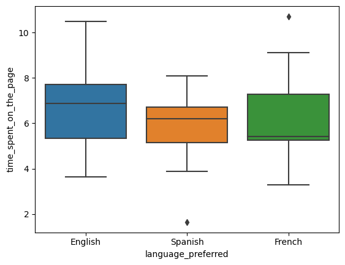

```python
df_new = df[df['landing_page'] == 'new']
sns.boxplot(x = 'language_preferred', y = 'time_spent_on_the_page', data = df_new)
plt.show()
```

### Paso 1: Definir las hipótesis nula y alternativa

> Hipótesis nula $H_0:$ No hay diferencia significativa en el tiempo dedicado a la nueva página entre los diferentes usuarios de idiomas.

> Hipótesis alternativa $H_a:$ Existe una diferencia significativa en el tiempo dedicado a la nueva página entre los diferentes usuarios de idiomas.

### Paso 2: Seleccione la prueba adecuada

Dado que queremos comparar el tiempo dedicado a la nueva página entre diferentes frupos de usuarios de idiomas, podemos utilizar un análisis de varianaza (ANOVA). El ANOVA nos permitirá determinar si hay diferencias significativas en el tiempo dedicado a la nueva pagina entre los distintos grupos de idiomas.

por lo que deberemos de comprobar los supuestos de normalidad e igualdad de varianza de la siguiente manera.

Prueba de Shapiro-Wilk Para validar el supuesto de normalidad, se aplica la prueba de Shapiro-Wilk a la variable de respuesta. La prueba de Shapiro-Wilk examina si la población de la quese extrae lamuestra sigue una distribución normal o no.

> $H_0:$ El tiempo dedicado a la nueva página sigue una distribución normal

contra la hipótesis alternativa

> $H_a:$ El tiempo dedicado a la nueva página no sigue una distribución normal

```python
from scipy.stats import shapiro

# find the p-value
w, p_value = shapiro(df_new['time_spent_on_the_page'])
print('The p-value is', p_value)
```

```
The p-value is 0.8040016293525696
```

Dado que el valor p de la prueba es más grande que el nivel de significancia del 5%, no podemos rechazar la hipótesis nula de que sigue una distribución normal.

Prueba de Levene Para validar la hipótesis de la varianza común, se aplica la prueba de Levene a los distintos grupos. La prueba de Levene comprueba si las diferentes muestras proceden de una población con una varianza común.

> $H_0$: Todas las varianzas poblacionales son iguales

> $H_a$: Al menos una varianza es diferente del resto

```python
from scipy.stats import levene

# Obtener los tiempos dedicados a la nueva página por idioma preferido
time_spent_English = df_new[df_new['language_preferred'] == "English"]['time_spent_on_the_page']
time_spent_French = df_new[df_new['language_preferred'] == "French"]['time_spent_on_the_page']
time_spent_Spanish = df_new[df_new['language_preferred'] == "Spanish"]['time_spent_on_the_page']

# Realizar la prueba de igualdad de varianzas (prueba de Levene)
statistic, p_value = levene(time_spent_English, time_spent_French, time_spent_Spanish)

# Imprimir los resultados
print("Prueba de igualdad de varianzas (Levene)")
print("---------------------------------------")
print("Grupo 'English':")
print("Número de observaciones:", len(time_spent_English))
print("Media:", time_spent_English.mean())
print("Varianza:", time_spent_English.var())
print("---------------------------------------")
print("Grupo 'French':")
print("Número de observaciones:", len(time_spent_French))
print("Media:", time_spent_French.mean())
print("Varianza:", time_spent_French.var())
print("---------------------------------------")
print("Grupo 'Spanish':")
print("Número de observaciones:", len(time_spent_Spanish))
print("Media:", time_spent_Spanish.mean())
print("Varianza:", time_spent_Spanish.var())
print("---------------------------------------")
print("Estadística de prueba de Levene:", statistic)
print("Valor p:", p_value)
```

```
Prueba de igualdad de varianzas (Levene)
---------------------------------------
Grupo 'English':
Número de observaciones: 16
Media: 6.66375
Varianza: 3.936851666666667
---------------------------------------
Grupo 'French':
Número de observaciones: 17
Media: 6.196470588235294
Varianza: 3.738011764705883
---------------------------------------
Grupo 'Spanish':
Número de observaciones: 17
Media: 5.835294117647059
Varianza: 2.3276264705882346
---------------------------------------
Estadística de prueba de Levene: 0.7736446756800186
Valor p: 0.46711357711340173
```

Dado que el valor p es mayor que el nivel de significación del 5 %, no podemos rechazar la hipótesis nula de la prueba de Levene.

### Paso 4: recopilar y preparar datos

```python
# Filtrar los datos para obtener solo los usuarios con tiempo dedicado a la nueva página
df_new_page_with_time = df_new_page.dropna(subset=['time_spent_on_the_page'])

# Obtener los tiempos dedicados a la nueva página por idioma preferido
time_spent_English = df_new_page_with_time[df_new_page_with_time['language_preferred'] == "English"]['time_spent_on_the_page']
time_spent_French = df_new_page_with_time[df_new_page_with_time['language_preferred'] == "French"]['time_spent_on_the_page']
time_spent_Spanish = df_new_page_with_time[df_new_page_with_time['language_preferred'] == "Spanish"]['time_spent_on_the_page']

# Calcular estadísticas de los tiempos dedicados por idioma
mean_time_English = time_spent_English.mean()
mean_time_French = time_spent_French.mean()
mean_time_Spanish = time_spent_Spanish.mean()

median_time_English = time_spent_English.median()
median_time_French = time_spent_French.median()
median_time_Spanish = time_spent_Spanish.median()

std_time_English = time_spent_English.std()
std_time_French = time_spent_French.std()
std_time_Spanish = time_spent_Spanish.std()

# Imprimir los resultados
print("Estadísticas de tiempo dedicado a la nueva página por idioma preferido:")
print("---------------------------------------------------------------------")
print("Idioma 'English':")
print("Número de observaciones:", len(time_spent_English))
print("Media:", mean_time_English)
print("Mediana:", median_time_English)
print("Desviación estándar:", std_time_English)
print("---------------------------------------------------------------------")
print("Idioma 'French':")
print("Número de observaciones:", len(time_spent_French))
print("Media:", mean_time_French)
print("Mediana:", median_time_French)
print("Desviación estándar:", std_time_French)
print("---------------------------------------------------------------------")
print("Idioma 'Spanish':")
print("Número de observaciones:", len(time_spent_Spanish))
print("Media:", mean_time_Spanish)
print("Mediana:", median_time_Spanish)
print("Desviación estándar:", std_time_Spanish)
print("---------------------------------------------------------------------")
```

```
Estadísticas de tiempo dedicado a la nueva página por idioma preferido:
---------------------------------------------------------------------
Idioma 'English':
Número de observaciones: 16
Media: 6.66375
Mediana: 6.865
Desviación estándar: 1.9841501119286986
---------------------------------------------------------------------
Idioma 'French':
Número de observaciones: 17
Media: 6.196470588235294
Mediana: 5.42
Desviación estándar: 1.9333938462470297
---------------------------------------------------------------------
Idioma 'Spanish':
Número de observaciones: 17
Media: 5.835294117647059
Mediana: 6.2
Desviación estándar: 1.5256560787373525
---------------------------------------------------------------------
```

### Paso 5: Calcular el valor p

```python
from scipy.stats import f_oneway
# find the p-value
test_stat, p_value = f_oneway(time_spent_English, time_spent_French, time_spent_Spanish)
# print the p-value
print('The p-value is', p_value)
```

```
The p-value is 0.43204138694325955
```

### Paso 6: Compare el valor p con $\alpha$

```python
# Nivel de significancia alfa (usualmente 0.05)
alfa = 0.05

if p_value < alfa:
    print("El valor p es menor que 𝛼 (", alfa, "), por lo tanto, rechazamos la hipótesis nula.")
else:
    print("El valor p es mayor o igual que 𝛼 (", alfa, "), por lo tanto, no rechazamos la hipótesis nula.")
```

```
El valor p es mayor o igual que 𝛼 ( 0.05 ), por lo tanto, no rechazamos la hipótesis nula.
```

### Paso 7: Extraer inferencia

No hay pruebas estadísticas para respaldar la idea de que el tiempo dedicado a la nueva página varía de manera significativa según el idioma preferido por los usuarios.

## Conclusión y recomendaciones comerciales

Para concluir podemos decir que los usuarios estan dedicando mas tiempo a la nueva pagina de inicio, lo que sugiere que su contenido resulta más atractivo y los alienta a suscribirse.

Además, la tasas de conversion en la nueva pagina supera a la de la anterior, lo que significa que más personas estan suscribiendose gracias a las nuevas implementaciones que se le han hecho a la pagina.

Es interesante ver que el tiempo de permanencia en la nueva pagina no varía dependiendo el idioma preferido, lo que nos puede demostrar que su atractivo es universal.

Basandonos en esto, es altamente recomendable que se siga utilizanod la nueva pagina, ya que ha demostrado ser efectiva.